# Denoising the complete data set with dada2

Ignasi

12/12/2019

# Set up

I try to specify here all variables that depend on the current data or system. Subsequent runs should only have to update this section to be generate the report in a diferent system or with different data. I also load libraries.

```r
library(dada2)
library(reactable)
library(tidyr)
library(ggplot2)
library(plyr)
library(DECIPHER)

DATADIR <- c('../../data/RUNGEN52_2019/joined', '../../data/RUNGEN66/joined')  # It works with any number of dirs!
FastqPattern <- '^[EL].*extendedFrags.fastq.gz'  # To distinguish input fastq files. Must be common to all dirs.
THREADS <- 60  # for multithreading, number of cores.
```

Below, I will have to assume that there are only two data directories, corresponding to the two sequencing batches.

# Learning (from) errors

```r
joined <- sort(list.files(DATADIR, pattern = FastqPattern, full.names = TRUE))

# In dada2's tutorial, I see this use of sapply, that I had not seen before. Interesting:
sample.names <- sapply(strsplit(joined, '/|.extendedFrags'), # this creates a list of lists,
                       '[',                                  # that's the extract-or-replace-parts-of-an-object function,
                       6)                                    # that's the argument to that function.
names(joined) <- sample.names   # They are in the same order.
sample.names
```

```
##   [1] "E10A"  "E10B"  "E10C"  "E11A"  "E11B"  "E11C"  "E12A"  "E12B"  "E12C"
##  [10] "E14A"  "E14B"  "E14D"  "E15A"  "E15C"  "E15D"  "E17A"  "E17B"  "E17C"
##  [19] "E17D"  "E19A"  "E19B"  "E19C"  "E19D"  "E20A"  "E20B"  "E20C"  "E22A"
##  [28] "E22B"  "E22D"  "E23B"  "E23C"  "E23D"  "E24A"  "E24B"  "E24C"  "E6A"
##  [37] "E6B"   "E6D"   "L10A"  "L10B"  "L10C"  "L10D"  "L11A"  "L11B"  "L11C"
##  [46] "L11D"  "L12A"  "L12B"  "L12C"  "L12D"  "L14A"  "L14B"  "L14C"  "L14D"
##  [55] "L15A"  "L15B"  "L15C"  "L17A"  "L17B"  "L17C"  "L17D"  "L19A"  "L19B"
##  [64] "L19C"  "L19D"  "L20A"  "L20B"  "L20CD" "L22A"  "L22B"  "L22C"  "L22D"
##  [73] "L23A"  "L23D"  "L24A"  "L24B"  "L6A"   "L6B"   "L6C"   "L6D"   "E22C"
##  [82] "E23A"  "E25A"  "E25B"  "E25C"  "E25D"  "E26A"  "E26B"  "E26C"  "E26D"
##  [91] "E27A"  "E27B"  "E27C"  "E28A"  "E28B"  "E28C"  "E28D"  "E29A"  "E29B"
## [100] "E29C"  "E29D"  "E30A"  "E30B"  "E30C"  "E30D"  "E31A"  "E31B"  "E31C"
## [109] "E31D"  "E33A"  "E33B"  "E33C"  "E33D"  "E35A"  "E35B"  "E35C"  "E35D"
## [118] "E36A"  "E36B"  "E36C"  "E36D"  "E38A"  "E38B"  "E38C"  "E38D"  "E39A"
## [127] "E39B"  "E39C"  "E39D"  "L23B"  "L24C"  "L25A"  "L25B"  "L25C"  "L25D"
## [136] "L26A"  "L26B"  "L26C"  "L26D"  "L27A"  "L27B"  "L27C"  "L28A"  "L28B"
## [145] "L28C"  "L28D"  "L29A"  "L29B"  "L29C"  "L29D"  "L30A"  "L30B"  "L30C"
## [154] "L30D"  "L31A"  "L31B"  "L31C"  "L31D"  "L33A"  "L33B"  "L33C"  "L33D"
## [163] "L35B"  "L35C"  "L35D"  "L36A"  "L36B"  "L36C"  "L36D"  "L38A"  "L38B"
## [172] "L38C"  "L38D"  "L39A"  "L39B"  "L39C"  "L39D"
```

The error-learning and dada algorithms do not support ambiguous `N` bases. I have checked (see `README.sh`) that the first and the third cycles of the second sequencing run produced a lot of Ns in reverse reads. I must trim the last 3 bases of the joined reads and then remove reads with Ns. It will create new fastq.gz files, unfortunately. Below I trim all reads, even those from the first batch, which do not have Ns in those last three positions. This way I remove variation only visible in the samples from the first batch. But make the identification of amplicon variants more consistent among samples. Otherwise, I could have used `collapseNoMismatch()` to count as equal variants that only differ in the length at the edges.

```r
filtFiles <- file.path('./filtered', paste0(sample.names, '.fastq.gz'))
filtOut <- filterAndTrim(joined, filtFiles, truncQ = 0, trimRight = 3, multithread = THREADS)
reactable(filtOut)
```

|  | reads.in | reads.out |
| --- | --- | --- |
| E10A.extendedFrags.fastq.gz | 82525 | 82523 |
| E10B.extendedFrags.fastq.gz | 54096 | 54095 |
| E10C.extendedFrags.fastq.gz | 82857 | 82854 |
| E11A.extendedFrags.fastq.gz | 65080 | 65080 |
| E11B.extendedFrags.fastq.gz | 78346 | 78345 |
| E11C.extendedFrags.fastq.gz | 83836 | 83834 |
| E12A.extendedFrags.fastq.gz | 61846 | 61842 |
| E12B.extendedFrags.fastq.gz | 92585 | 92582 |
| E12C.extendedFrags.fastq.gz | 136116 | 136111 |
| E14A.extendedFrags.fastq.gz | 117758 | 117755 |

[output cut: 167 more lines]

```r
errors <- learnErrors(filtFiles, multithread = THREADS, randomize=TRUE)
```

```
## 109463871 total bases in 250482 reads from 3 samples will be used for learning the error rates.
```

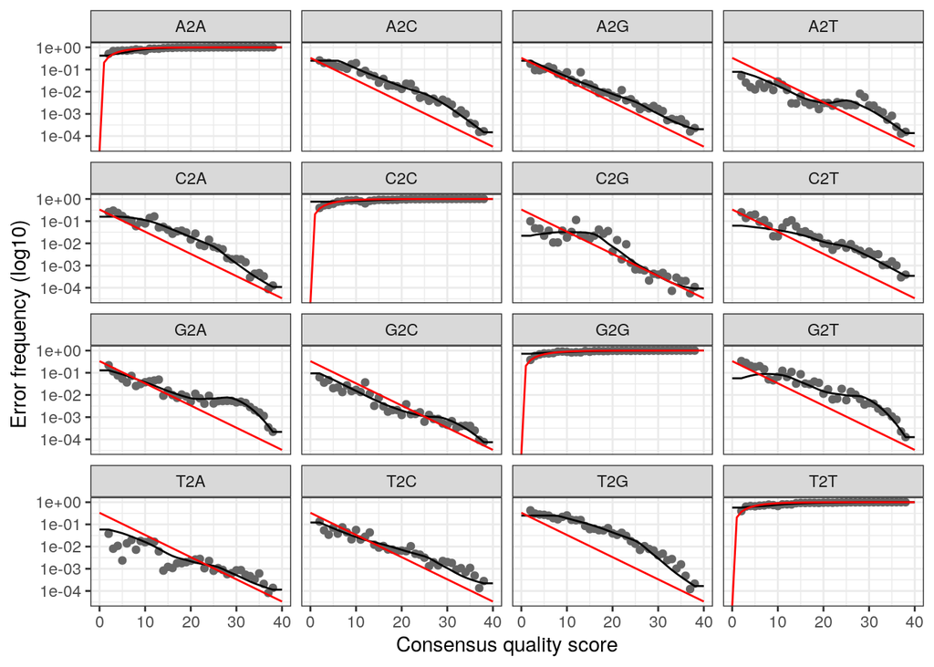

```r
plotErrors(errors, nominalQ = TRUE)
```

# De-noising and removing chimeras.

`dada` produces a *list* of `dada-class` objects: one per sample. I run it in its own chunk, because it is the longest step. That way, I will only run it again if I change either its input or the code in that chunk. All subsequent code can be edited without triggering the update of the dada results. Note the `cache.lazy=FALSE` option. It is necessray to unset the lazy load of cache results, which would otherwise fail to load large vectors.

```r
denoised <- dada(filtFiles, errors, pool = TRUE, multithread = THREADS)
```

```
## 177 samples were pooled: 14334800 reads in 2917437 unique sequences.
```

```r
SeqTab <- makeSequenceTable(denoised)
SeqTabNoChim <- removeBimeraDenovo(SeqTab, method = 'per-sample')
```

# Summary

Before assigning taxonomy, it may be a good time to summarize the results obtained this far.

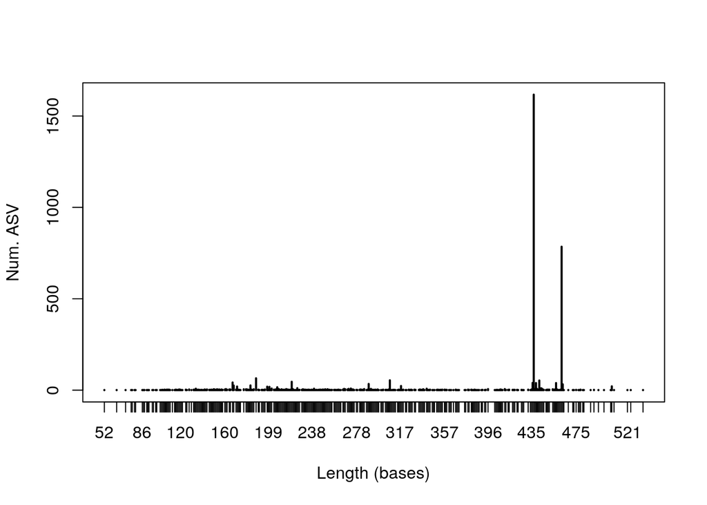

```r
plot(table(nchar(getSequences(SeqTabNoChim))), xlab='Length (bases)', ylab='Num. ASV')
```

The dada2 tutorial recommends to check the length distribution and remove unexpectedly short sequences. They could be a result of inspecific binding of primers. But where to cut? Preliminar alignments make it evident that many sequences must lack homology. I run some blasts manually with sequences of decreasing length. The first length of a sequence that retrieved a *Drosophila* hit was 432. Some sequences with intermediate length between the two most abundant lengths seem to come from the *Drosophila* genome. And most sequences longer than 463 are *Drosophila*’s.

```r
SeqTabNoChim <- SeqTabNoChim[,nchar(colnames(SeqTabNoChim)) > 432 & nchar(colnames(SeqTabNoChim)) < 464]
alignment <- AlignSeqs(RNAStringSet(DNAStringSet(colnames(SeqTabNoChim))))
```

```
## Determining distance matrix based on shared 8-mers:
## ================================================================================
##
## Time difference of 102.84 secs
##
## Clustering into groups by similarity:
## ================================================================================
##
## Time difference of 2.12 secs
##
## Aligning Sequences:
## ================================================================================
##
## Time difference of 21.56 secs
##
## Iteration 1 of 2:
## Computing RNA Secondary Structures:
## ================================================================================
##
## Time difference of 7.32 secs
##
## Determining distance matrix based on alignment:
## ================================================================================
##
## Time difference of 9.89 secs
##
## Reclustering into groups by similarity:
## ================================================================================
##
## Time difference of 1.96 secs
##
## Realigning Sequences:
## ================================================================================
##
## Time difference of 20.62 secs
##
## Iteration 2 of 2:
## Computing RNA Secondary Structures:
## ================================================================================
##
```

[output cut: 10 more lines]

```
## Time difference of 1.93 secs
##
## Realigning Sequences:
## ================================================================================
##
## Time difference of 4.66 secs
## Computing RNA Secondary Structures:
## ================================================================================
##
## Time difference of 7.3 secs
##
## Refining the alignment:
## ================================================================================
##
## Time difference of 2.47 secs
```

```r
BrowseSeqs(alignment, htmlFile='alignment.html', openURL=FALSE)
```

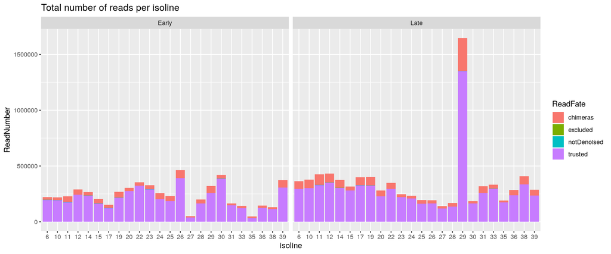

```r
## Rows in filtOut correspond to those in joined, which are named by sample.names. No need to extract the names again:
# sample.names <- sapply(strsplit(rownames(filtOut), ".", fixed=TRUE), '[', 1)
m <- regexpr('[0-9]+', sample.names)
readNumber <- data.frame(sample = sample.names,
                         age = factor(NA, levels=c('Early','Late')),
                         isoline = factor(as.numeric(regmatches(sample.names, m))),
                         seqBatch = factor(NA, levels=c(1,2)),
                         excluded = filtOut[,1] - filtOut[,2],
                         notDenoised = filtOut[,2] - rowSums(SeqTab),
                         chimeras = rowSums(SeqTab) - rowSums(SeqTabNoChim),
                         trusted = rowSums(SeqTabNoChim))
readNumber$age[grep('^E', readNumber$sample)] <- 'Early'
readNumber$age[grep('^L', readNumber$sample)] <- 'Late'
FirstBatchSamples <- sapply(strsplit(list.files(DATADIR[1], pattern = '^[EL].*extendedFrags.fastq.gz'),
                                     '.', fixed = TRUE),
                            '[', 1)
readNumber$seqBatch[readNumber$sample %in% FirstBatchSamples] <- 1
readNumber$seqBatch[!(readNumber$sample %in% FirstBatchSamples)] <- 2
LongReadNumber <- pivot_longer(readNumber, cols = c('excluded','notDenoised','chimeras','trusted'),
                               names_to = 'ReadFate', values_to = 'ReadNumber')
ggplot(LongReadNumber, mapping=aes(x=isoline, y=ReadNumber, fill=ReadFate)) + geom_col() + facet_wrap(~age) +
  ggtitle('Total number of reads per isoline')
```

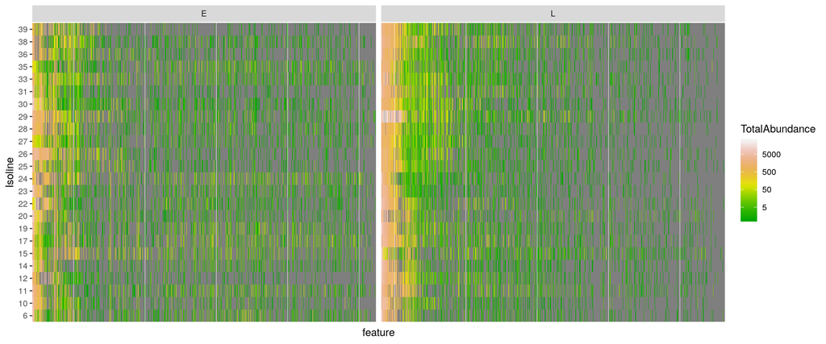

```r
FeatDF <- as.data.frame(t(SeqTabNoChim))
FeatDF$feature <- factor(rownames(FeatDF), levels = rownames(FeatDF), ordered = TRUE) # this adds a column.
rownames(FeatDF) <- NULL
LongFeat <- pivot_longer(FeatDF, cols = 1:(length(FeatDF)-1), names_to = c('Age', 'Isoline', 'Batch'),
                         names_pattern = "([LE])([0-9]+)([A-Z]+)", values_to = 'Abundance')
LongFeat$Isoline <- factor(as.numeric(LongFeat$Isoline),
                           levels = sort(as.numeric(unique(LongFeat$Isoline))),
                           ordered = TRUE)
SummFeat <- ddply(LongFeat, .variables = c('feature', 'Age', 'Isoline'), summarize,
                  TotalAbundance = sum(Abundance))
ggplot(data = SummFeat, mapping = aes(x = feature, y = Isoline, fill = TotalAbundance)) +
  geom_tile() + facet_wrap(~Age) +
  scale_fill_gradientn(trans='log', colors=terrain.colors(10), breaks=c(5,50,500,5000)) +
  theme(axis.text.x = element_blank(), axis.ticks.x = element_blank())
```

```r
save(SeqTabNoChim, file='denoising.RData')
```